# 市场观察

2016/06/15

## 一、指数估值

### (一)指数动态市盈率

核心指数成分股的动态市盈率中位数走势如下图所示：

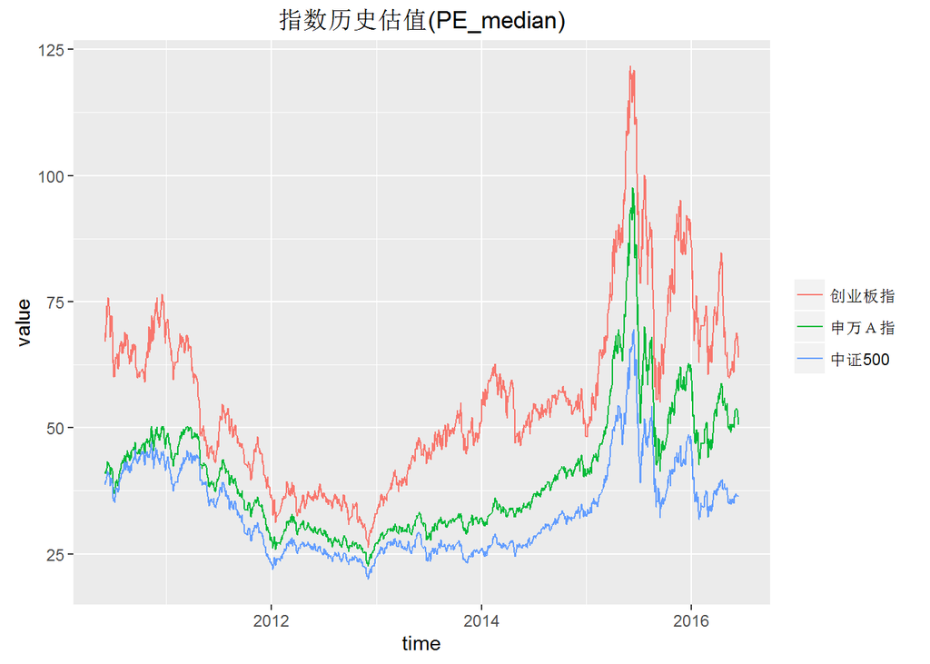

### (二)指数动态市盈率百分位

核心指数上述数据的百分位走势如下图所示：

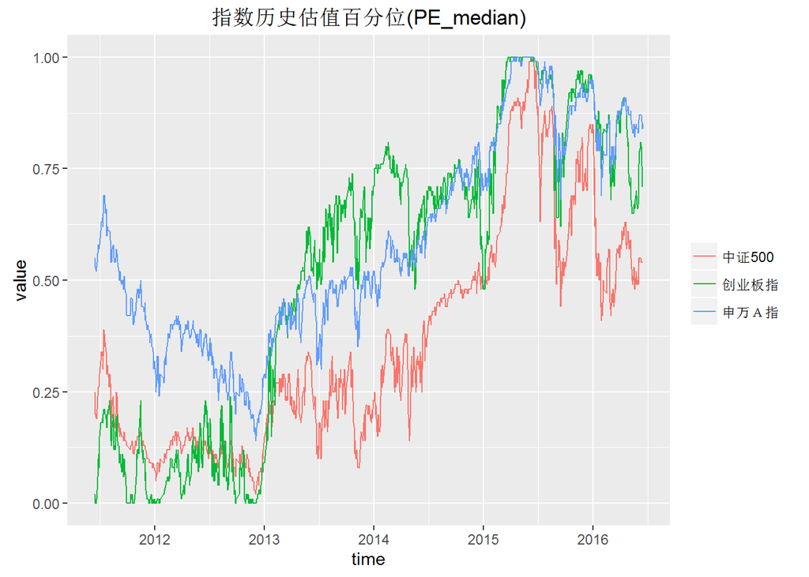

### (三)指数估值概览

纳入观察的18只指数最新的估值情况如下表：

| 日期 | 指数代码 | 指数简称 | 动态市盈率 | 上周动态市盈率 | 市盈率百分位 | 上周市盈率百分位 | 动态市净率 | 市净率百分位 |
| --- | --- | --- | --- | --- | --- | --- | --- | --- |
| 2016-06-14 | EI000979 | 大宗商品 | 42.32 | 40.09 | 0.90 | 0.88 | 2.38 | 0.37 |
| 2016-06-14 | EI000819 | 有色金属 | 55.14 | 45.08 | 0.85 | 0.71 | 4.13 | 0.87 |
| 2016-06-14 | EI801003 | 申万Ａ指 | 51.24 | 53.76 | 0.85 | 0.87 | 4.35 | 0.67 |
| 2016-06-14 | EI000805 | A股资源 | 40.68 | 29.08 | 0.80 | 0.65 | 2.36 | 0.48 |
| 2016-06-14 | EI000998 | 中证TMT | 57.06 | 60.56 | 0.74 | 0.79 | 5.64 | 0.72 |
| 2016-06-14 | EI399005 | 中小板指P | 43.01 | 45.06 | 0.74 | 0.81 | 5.03 | 0.57 |
| 2016-06-14 | EI399959 | 军工指数 | 86.30 | 89.83 | 0.73 | 0.78 | 5.72 | 0.74 |
| 2016-06-14 | EI399006 | 创业板指 | 63.89 | 67.75 | 0.71 | 0.79 | 7.02 | 0.73 |
| 2016-06-14 | EI801120 | 申万食品饮料 | 41.53 | 44.50 | 0.60 | 0.70 | 4.14 | 0.47 |
| 2016-06-14 | EI000905 | 中证500 | 36.53 | 36.93 | 0.54 | 0.55 | 3.32 | 0.49 |
| 2016-06-14 | EI399330 | 深证100 | 25.98 | 26.93 | 0.48 | 0.53 | 3.56 | 0.50 |
| 2016-06-14 | EI000933 | 中证医药 | 36.26 | 37.95 | 0.46 | 0.61 | 4.09 | 0.11 |
| 2016-06-14 | EI000300 | 沪深300 | 21.27 | 21.99 | 0.45 | 0.49 | 2.40 | 0.41 |
| 2016-06-14 | EI000808 | 医药生物 | 38.27 | 39.68 | 0.41 | 0.54 | 4.87 | 0.37 |
| 2016-06-14 | EI000932 | 中证消费 | 31.06 | 31.68 | 0.41 | 0.44 | 4.18 | 0.40 |
| 2016-06-14 | EI000827 | 中证环保 | 34.47 | 36.15 | 0.28 | 0.39 | 3.62 | 0.50 |
| 2016-06-14 | EI000934 | 中证金融 | 14.62 | 15.24 | 0.17 | 0.27 | 2.15 | 0.42 |
| 2016-06-14 | EI000016 | 上证50 | 11.57 | 12.15 | 0.05 | 0.10 | 1.41 | 0.01 |

## 二、基差

### (一)基差走势

三大股指期货隔季合约基差走势如下图：

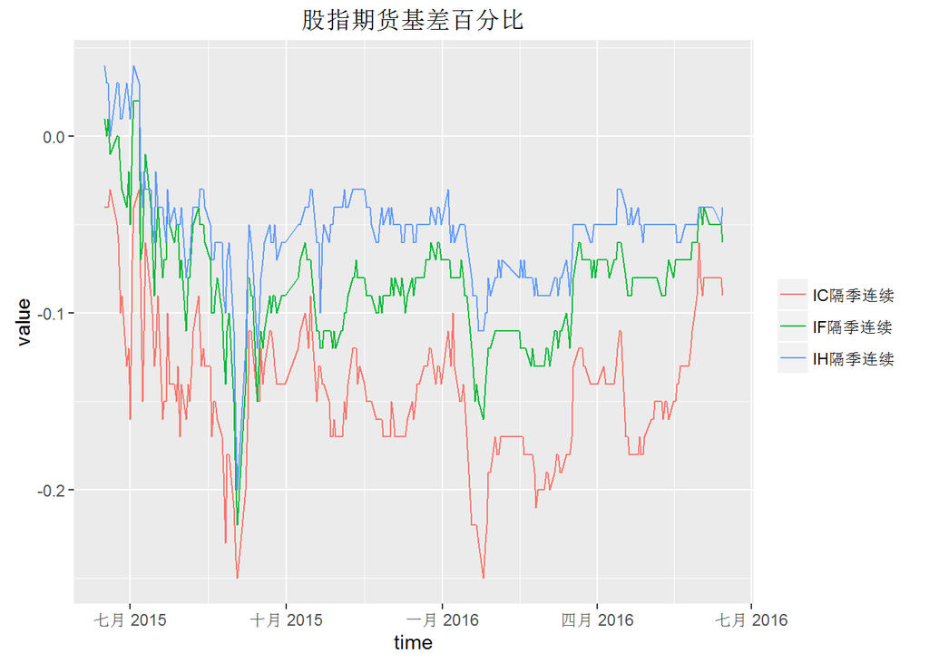

### (二)基差概况

三大股指期货连续合约基差概况如下表：

| 日期 | 合约简称 | 合约收盘价 | 基差 | 基差百分比 | 上周基差 | 上周基差百分比 |
| --- | --- | --- | --- | --- | --- | --- |
| 2016-06-14 | IH当月连续 | 2084.0 | -11.02 | -0.01 | -9.84 | 0.00 |
| 2016-06-14 | IH下月连续 | 2058.8 | -36.22 | -0.02 | -34.64 | -0.02 |
| 2016-06-14 | IH下季连续 | 2031.6 | -63.42 | -0.03 | -57.64 | -0.03 |
| 2016-06-14 | IH隔季连续 | 2005.6 | -89.42 | -0.04 | -84.24 | -0.04 |
| 2016-06-14 | IF当月连续 | 3050.4 | -25.58 | -0.01 | -11.93 | 0.00 |
| 2016-06-14 | IF下月连续 | 3009.6 | -66.38 | -0.02 | -48.93 | -0.02 |
| 2016-06-14 | IF下季连续 | 2948.0 | -127.98 | -0.04 | -90.33 | -0.03 |
| 2016-06-14 | IF隔季连续 | 2897.0 | -178.98 | -0.06 | -138.33 | -0.04 |
| 2016-06-14 | IC当月连续 | 5723.4 | -39.36 | -0.01 | -29.00 | 0.00 |
| 2016-06-14 | IC下月连续 | 5623.8 | -138.96 | -0.02 | -133.00 | -0.02 |
| 2016-06-14 | IC下季连续 | 5439.0 | -323.76 | -0.06 | -270.80 | -0.04 |
| 2016-06-14 | IC隔季连续 | 5232.6 | -530.16 | -0.09 | -452.60 | -0.08 |

## 三、套利

### (一)复牌股票套利

近两天复牌股票套利情况如下表：

[1] “无复牌股票套利”

## 四、择时

**任何指标都不能单一而绝对的发出买入卖出信号**，一个相对合理的择时模型应该是**基本面**和**技术面**的结合。以下关于技术分析的探索，还须和上面基于指数估值的探索相结合，至于如何结合，还需要进一步的研究。

### (一)大盘均线强弱指数

大盘均线强弱指数在一定程度上可以视为一个反转指标，当大盘均线得分接近8分时，预示市场接近顶部，当大盘均线得分接近0分时，预示市场接近底部。  
其原理是根据申万28个一级行业走势与其8均线(8,13,21,34,55,89,144,233)组合构造而来，譬如申万电子EI801080收盘价在8根均线之上，记为8分，在7根均线之上记为7分，以此类推，最后求28个一级行业的平均得分。  
大盘均线强弱指数近一年来走势如下图：

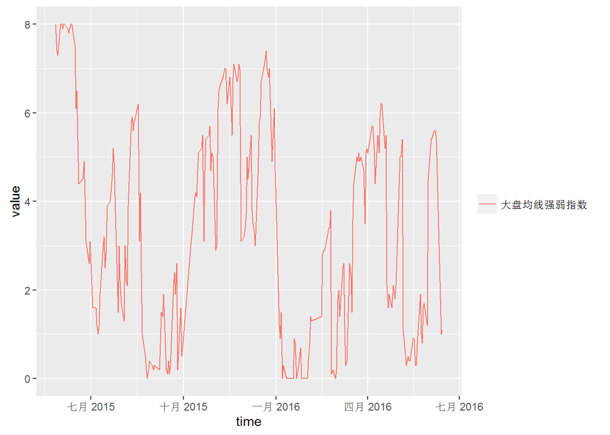

申万一级行业的最新得分及上周得分见下表：

| 日期 | 指数代码 | 指数名称 | 最新值 | 上周值 |
| --- | --- | --- | --- | --- |
| 2016-06-14 | EI801050 | 申万有色金属 | 7 | 8 |
| 2016-06-14 | EI801120 | 申万食品饮料 | 7 | 8 |
| 2016-06-14 | EI801080 | 申万电子 | 4 | 8 |
| 2016-06-14 | EI801110 | 申万家用电器 | 4 | 7 |
| 2016-06-14 | EI801730 | 申万电气设备 | 2 | 6 |
| 2016-06-14 | EI801880 | 申万汽车 | 2 | 6 |
| 2016-06-14 | EI801740 | 申万国防军工 | 1 | 4 |
| 2016-06-14 | EI801770 | 申万通信 | 1 | 6 |
| 2016-06-14 | EI801780 | 申万银行 | 1 | 7 |
| 2016-06-14 | EI801890 | 申万机械设备 | 1 | 6 |
| 2016-06-14 | EI801010 | 申万农林牧渔 | 0 | 6 |
| 2016-06-14 | EI801020 | 申万采掘 | 0 | 3 |
| 2016-06-14 | EI801030 | 申万化工 | 0 | 6 |
| 2016-06-14 | EI801040 | 申万钢铁 | 0 | 3 |
| 2016-06-14 | EI801130 | 申万纺织服装 | 0 | 5 |
| 2016-06-14 | EI801140 | 申万轻工制造 | 0 | 6 |
| 2016-06-14 | EI801150 | 申万医药生物 | 0 | 6 |
| 2016-06-14 | EI801160 | 申万公用事业 | 0 | 4 |
| 2016-06-14 | EI801170 | 申万交通运输 | 0 | 4 |
| 2016-06-14 | EI801180 | 申万房地产 | 0 | 4 |
| 2016-06-14 | EI801200 | 申万商业贸易 | 0 | 5 |
| 2016-06-14 | EI801210 | 申万休闲服务 | 0 | 3 |
| 2016-06-14 | EI801230 | 申万综合 | 0 | 5 |
| 2016-06-14 | EI801710 | 申万建筑材料 | 0 | 5 |
| 2016-06-14 | EI801720 | 申万建筑装饰 | 0 | 3 |
| 2016-06-14 | EI801750 | 申万计算机 | 0 | 6 |
| 2016-06-14 | EI801760 | 申万传媒 | 0 | 6 |
| 2016-06-14 | EI801790 | 申万非银金融 | 0 | 6 |

### (二)LLT及均线择时

LLT是参考广发的一个择时模型，跟踪了一段时间，表现还不错，所以自己重现了一下。创业板的择时直接用30天均线。择时模型的信号都依赖于收盘价，所以当日收盘后发出买入信号，次日开盘才能买入，单次交易成本千一。  
择时模型和指数本身的净值走势如下图：

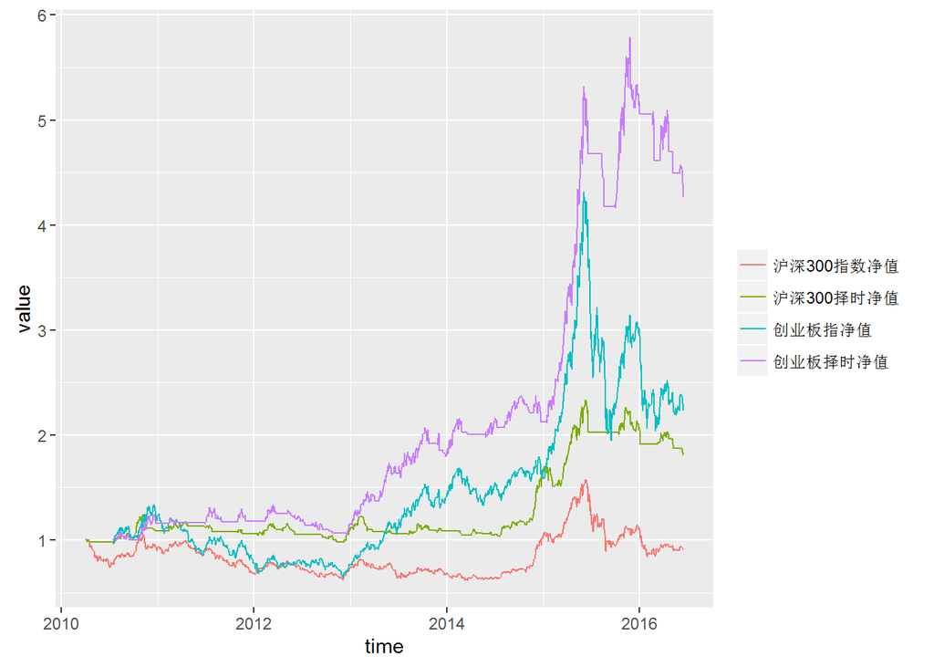

择时模型和指数的收益率统计如下表：

|  | 沪深300指 | 沪深300LLT | 创业板指 | 创业板MA |
| --- | --- | --- | --- | --- |
| 年化收益率 | -1.6 | 10.4 | 15.1 | 29.0 |
| 年化波动率 | 26.0 | 16.5 | 35.0 | 24.1 |
| 年化Sharpe值 | -6.2 | 63.1 | 43.2 | 120.0 |
| 最大回撤 | 46.7 | 22.6 | 54.9 | 26.4 |

择时模型最近10个交易日的信号如下表：

| 日期 | 沪深300收盘价 | 沪深300择时信号 | 创业板收盘价 | 创业板择时信号 |
| --- | --- | --- | --- | --- |
| 2016-05-30 | 3066.709 |  | 2058.518 |  |
| 2016-05-31 | 3169.560 | buy | 2159.800 | buy |
| 2016-06-01 | 3160.547 | hold | 2168.820 | hold |
| 2016-06-02 | 3167.100 | hold | 2188.558 | hold |
| 2016-06-03 | 3189.325 | hold | 2204.974 | hold |
| 2016-06-06 | 3178.788 | hold | 2199.301 | hold |
| 2016-06-07 | 3177.054 | hold | 2196.727 | hold |
| 2016-06-08 | 3163.986 | hold | 2186.544 | hold |
| 2016-06-13 | 3066.341 | sell | 2054.707 | sell |
| 2016-06-14 | 3075.983 |  | 2058.314 |  |